# Project 2

### CS 5/7394 - Applied Machine Learning

- **Due** - March 11 @ 11:59 pm pushed to Github repo
- **Teams** - You can do this project solo or in pairs. Not 3, not 4 not 5... Max of 2. If a 5394 student pairs with a 7394 student, the pair needs to do the 7394 work.

Below are 6 Kaggle Datasets. You will choose 1 to work with for this project.

- [Airfare Prediction Dataset](https://www.kaggle.com/zwartfreak/airline-fare-prediction)
- [Chinese Rest Holiday Dataset](https://www.kaggle.com/holoong9291/chinese-rest-holiday-dataset-2020-to-2022)
- [Jigsaw Toxic Comment Classification Challenge](https://www.kaggle.com/julian3833/jigsaw-toxic-comment-classification-challenge?select=train.csv)
- [Latest Covid 19 Dataset Worldwide](https://www.kaggle.com/sandhyakrishnan02/latest-covid-19-dataset-worldwide)
- [Trains](https://www.kaggle.com/vahidehdashti/machinelearningdatabase-trains?select=trains-original.data)
- [Football Data top 5 Leagues](https://www.kaggle.com/sanjeetsinghnaik/football-data-top-5-leagues)

Merging disparate datasets is a staple of the data exploration process. Therefore, for which ever data set above that you choose, you will need to independently find **an additional** dataset to merge with your selection. The only requirement is that it add to the richness of the original dataset. Students in the 7000-level version of the class need to find two additional data sets to merge with the original selection.

*Note*: If you want to start with a different data set, you need to get Fontenot's OK first.

### Your Tasks

Below, there are cells that provide directions on what to do for the project.

You can insert as many cells between the ones below as you'd like, but please **Do NOT** change the cells already provided.

### Part 1 - Getting Started

- Import libraries
- Load original Data (which ever one you chose from the provided list) into a data frame.
- Load your additional data set(s) into a data frame.
- In a markdown cell, provide a brief description of your the data sets you've chosen to work with.
- Develop a list of 3 - 4 questions that you hope to be able to answer after the exploration of the data and write them in this section.

```python
%matplotlib inline
import numpy as np
import pandas as pd
import matplotlib.pyplot as plt
import seaborn as sns
import nbconvert
import datetime
```

#### Original Dataset

```python
# !kaggle datasets download -d zwartfreak/airline-fare-prediction
```

```python
flights_df = pd.read_excel('flights.xlsx')
flights_df.head()
```

|  | Airline | Date_of_Journey | Source | Destination | Route | Dep_Time | Arrival_Time | Duration | Total_Stops | Additional Info | Price |
| --- | --- | --- | --- | --- | --- | --- | --- | --- | --- | --- | --- |
| 0 | IndiGo | 24/03/2019 | Banglore | New Delhi | BLR → DEL | 22:20 | 01:10 22 Mar | 2h 50m | non-stop | No info | 3898 |
| 1 | Air India | 1/05/2019 | Kolkata | Banglore | CCU → IXR → BBI → BLR | 05:50 | 13:15 | 7h 25m | 2 stops | No info | 7663 |
| 2 | Jet Airways | 9/06/2019 | Delhi | Cochin | DEL → LKO → BOM → COK | 09:25 | 04:25 10 Jun | 19h | 2 stops | No info | 13883 |
| 3 | IndiGo | 12/05/2019 | Kolkata | Banglore | CCU → NAG → BLR | 18:05 | 23:30 | 5h 25m | 1 stop | No info | 6219 |
| 4 | IndiGo | 01/03/2019 | Banglore | New Delhi | BLR → NAG → DEL | 16:50 | 21:35 | 4h 45m | 1 stop | No info | 13303 |

#### 2nd Dataset

```python
# !kaggle datasets download -d mabusalah/brent-oil-prices
```

```python
oil_df = pd.read_csv('BrentOilPrices.csv')
oil_df.head()
```

|  | Date | Price |
| --- | --- | --- |
| 0 | 20-May-87 | 18.63 |
| 1 | 21-May-87 | 18.45 |
| 2 | 22-May-87 | 18.55 |
| 3 | 25-May-87 | 18.60 |
| 4 | 26-May-87 | 18.63 |

#### 3rd Dataset

```python
# !kaggle datasets download -d sudalairajkumar/daily-temperature-of-major-cities
```

```python
temp_df = pd.read_csv('city_temperature.csv')
temp_df.head()
```

|  | Region | Country | State | City | Month | Day | Year | AvgTemperature |
| --- | --- | --- | --- | --- | --- | --- | --- | --- |
| 0 | Africa | Algeria | NaN | Algiers | 1 | 1 | 1995 | 64.2 |
| 1 | Africa | Algeria | NaN | Algiers | 1 | 2 | 1995 | 49.4 |
| 2 | Africa | Algeria | NaN | Algiers | 1 | 3 | 1995 | 48.8 |
| 3 | Africa | Algeria | NaN | Algiers | 1 | 4 | 1995 | 46.4 |
| 4 | Africa | Algeria | NaN | Algiers | 1 | 5 | 1995 | 47.9 |

#### Datasets Description

Questions:  
What is the level of correlation between oil prices and airfare? Is temperature a predictor of flight price? How strong? Which data features strongly relate to the flight price? Can the combined dataset perform better than the originl on the prediction problem?

### Part 2 - Data Inspection

Write some code to summarize the datasets. Think about the following questions:

- What type of data is each variable? (think like a data scientist here, not a computer scientist)
- What is the total size of the data sets?
- What time boundaries are there in the dataset? IOW, what time frame do they span?
- Are there any missing values in any of the variables?

Do this with Intentionality. Don't skimp.

#### Flight Data

```python
flights_df.info()
```

```
<class 'pandas.core.frame.DataFrame'>
RangeIndex: 10683 entries, 0 to 10682
Data columns (total 11 columns):
 #   Column           Non-Null Count  Dtype
---  ------           --------------  -----
 0   Airline          10683 non-null  object
 1   Date_of_Journey  10683 non-null  object
 2   Source           10683 non-null  object
 3   Destination      10683 non-null  object
 4   Route            10682 non-null  object
 5   Dep_Time         10683 non-null  object
 6   Arrival_Time     10683 non-null  object
 7   Duration         10683 non-null  object
 8   Total_Stops      10682 non-null  object
 9   Additional Info  10683 non-null  object
 10  Price            10683 non-null  int64
dtypes: int64(1), object(10)
memory usage: 918.2+ KB
```

```python
flights_df.isnull().sum()
```

```
Airline            0
Date_of_Journey    0
Source             0
Destination        0
Route              1
Dep_Time           0
Arrival_Time       0
Duration           0
Total_Stops        1
Additional Info    0
Price              0
dtype: int64
```

```python
flights_df.dropna(inplace=True)
```

```python
flights_df.info()
```

```
<class 'pandas.core.frame.DataFrame'>
Int64Index: 10682 entries, 0 to 10682
Data columns (total 11 columns):
 #   Column           Non-Null Count  Dtype
---  ------           --------------  -----
 0   Airline          10682 non-null  object
 1   Date_of_Journey  10682 non-null  object
 2   Source           10682 non-null  object
 3   Destination      10682 non-null  object
 4   Route            10682 non-null  object
 5   Dep_Time         10682 non-null  object
 6   Arrival_Time     10682 non-null  object
 7   Duration         10682 non-null  object
 8   Total_Stops      10682 non-null  object
 9   Additional Info  10682 non-null  object
 10  Price            10682 non-null  int64
dtypes: int64(1), object(10)
memory usage: 1001.4+ KB
```

So one row was dropped.  
The printout also shows type of each column. Date_of_Journey, Dep_Time, Arrival_Time should not be object type, more on that later.

```python
# flights_df['Date_of_Journey'] = [datetime.datetime.strptime(x,'%d/%m/%Y').strftime('%d-%m-%Y') for x in flights_df['Date_of_Journey']]
# flights_df['Date_of_Journey']
```

```python
flights_df['Date_of_Journey'] = pd.to_datetime(flights_df['Date_of_Journey'], format= '%d/%m/%Y')
flight_dates = flights_df['Date_of_Journey'].dt.strftime('%d-%m-%Y')
```

```python
flights_df['Arrival_Time'] = pd.to_datetime(flights_df['Arrival_Time'])
flights_df['Dep_Time'] = pd.to_datetime(flights_df['Dep_Time'])
```

```python
flights_df.dtypes
```

```
Airline                    object
Date_of_Journey    datetime64[ns]
Source                     object
Destination                object
Route                      object
Dep_Time           datetime64[ns]
Arrival_Time       datetime64[ns]
Duration                   object
Total_Stops                object
Additional Info            object
Price                       int64
dtype: object
```

```python
sorted_dates = sorted(flights_df['Date_of_Journey'])
print('flights time boundries: {} - {}'.format(sorted_dates[0], sorted_dates[-1]))
```

```
flights time boundries: 2019-03-01 00:00:00 - 2019-06-27 00:00:00
```

```python
flights_df['Dep_Time_h'] = flights_df['Dep_Time'].dt.hour
flights_df['Dep_Time_m'] = flights_df['Dep_Time'].dt.minute
```

```python
flights_df['Arv_Time_h'] = flights_df['Arrival_Time'].dt.hour
flights_df['Arv_Time_m'] = flights_df['Arrival_Time'].dt.minute
```

```python
Dur_in_mins = []
for dur in flights_df['Duration']:
    l = dur.split(' ')
    mins = 0
    if len(l) == 2:
        mins = int(l[0][0:-1]) * 60 + int(l[1][0:-1])
    else:
        if l[0][-1] == 'h':
            mins = int(l[0][0:-1]) * 60
        else:
            mins = int(l[0][0:-1])

    Dur_in_mins.append(mins)
flights_df['Duration_mins'] = Dur_in_mins
```

```python
flights_df.drop(columns=['Duration', 'Arrival_Time', 'Dep_Time'], inplace = True)
```

```python
flights_df.head()
```

|  | Airline | Date_of_Journey | Source | Destination | Route | Total_Stops | Additional Info | Price | Dep_Time_h | Dep_Time_m | Arv_Time_h | Arv_Time_m | Duration_mins |
| --- | --- | --- | --- | --- | --- | --- | --- | --- | --- | --- | --- | --- | --- |
| 0 | IndiGo | 2019-03-24 | Banglore | New Delhi | BLR → DEL | non-stop | No info | 3898 | 22 | 20 | 1 | 10 | 170 |
| 1 | Air India | 2019-05-01 | Kolkata | Banglore | CCU → IXR → BBI → BLR | 2 stops | No info | 7663 | 5 | 50 | 13 | 15 | 445 |
| 2 | Jet Airways | 2019-06-09 | Delhi | Cochin | DEL → LKO → BOM → COK | 2 stops | No info | 13883 | 9 | 25 | 4 | 25 | 1140 |
| 3 | IndiGo | 2019-05-12 | Kolkata | Banglore | CCU → NAG → BLR | 1 stop | No info | 6219 | 18 | 5 | 23 | 30 | 325 |
| 4 | IndiGo | 2019-03-01 | Banglore | New Delhi | BLR → NAG → DEL | 1 stop | No info | 13303 | 16 | 50 | 21 | 35 | 285 |

```python
flights_df.dtypes
```

```
Airline                    object
Date_of_Journey    datetime64[ns]
Source                     object
Destination                object
Route                      object
Total_Stops                object
Additional Info            object
Price                       int64
Dep_Time_h                  int64
Dep_Time_m                  int64
Arv_Time_h                  int64
Arv_Time_m                  int64
Duration_mins               int64
dtype: object
```

#### Oil Data

```python
oil_df.info()
```

```
<class 'pandas.core.frame.DataFrame'>
RangeIndex: 8554 entries, 0 to 8553
Data columns (total 2 columns):
 #   Column  Non-Null Count  Dtype
---  ------  --------------  -----
 0   Date    8554 non-null   object
 1   Price   8554 non-null   float64
dtypes: float64(1), object(1)
memory usage: 133.8+ KB
```

```python
oil_df.loc[list(np.random.choice(oil_df.shape[0], 5))]
```

|  | Date | Price |
| --- | --- | --- |
| 6388 | 24-Jul-12 | 103.57 |
| 1443 | 8-Jan-93 | 17.23 |
| 3010 | 29-Mar-99 | 14.34 |
| 8129 | 31-May-19 | 66.78 |
| 7951 | 14-Sep-18 | 77.87 |

```python
clean_dates = []
dates_to_drop = []
processed = 0
for i,date in enumerate(oil_df['Date']):
    try:
        d = datetime.datetime.strptime(date,'%d-%b-%y').strftime('%d-%m-%Y')
        oil_df['Date'] = oil_df['Date'].replace([date], d)
        processed += 1
    except:
        dates_to_drop.append(i)
        pass

processed
```

```
8360
```

```python
oil_df['Date']
```

```
0         20-05-1987
1         21-05-1987
2         22-05-1987
3         25-05-1987
4         26-05-1987
            ...
8549    Jan 19, 2021
8550    Jan 20, 2021
8551    Jan 21, 2021
8552    Jan 22, 2021
8553    Jan 25, 2021
Name: Date, Length: 8554, dtype: object
```

```python
oil_df['Date'][dates_to_drop]
```

```
8360    Apr 22, 2020
8361    Apr 23, 2020
8362    Apr 24, 2020
8363    Apr 27, 2020
8364    Apr 28, 2020
            ...
8549    Jan 19, 2021
8550    Jan 20, 2021
8551    Jan 21, 2021
8552    Jan 22, 2021
8553    Jan 25, 2021
Name: Date, Length: 194, dtype: object
```

```python
oil_df.drop(index=dates_to_drop, inplace=True)
```

```python
oil_df['Year'] = pd.to_datetime(oil_df['Date']).dt.year
oil_df['Year'] = oil_df['Year'].astype(str)
```

```python
oil_df = oil_df[oil_df['Year'] == '2019']
oil_df.drop(columns=['Year'], inplace=True)
oil_df.shape
```

```
(258, 2)
```

#### Temperature Data

```python
temp_df.info()
```

```
<class 'pandas.core.frame.DataFrame'>
RangeIndex: 2906327 entries, 0 to 2906326
Data columns (total 8 columns):
 #   Column          Dtype
---  ------          -----
 0   Region          object
 1   Country         object
 2   State           object
 3   City            object
 4   Month           int64
 5   Day             int64
 6   Year            int64
 7   AvgTemperature  float64
dtypes: float64(1), int64(3), object(4)
memory usage: 177.4+ MB
```

```python
temp_df.isnull().sum()
```

```
Region                  0
Country                 0
State             1450990
City                    0
Month                   0
Day                     0
Year                    0
AvgTemperature          0
dtype: int64
```

```python
temp_df = temp_df[temp_df['Country'] == 'India'].reset_index(drop= True)
temp_df.info()
```

```
<class 'pandas.core.frame.DataFrame'>
RangeIndex: 37063 entries, 0 to 37062
Data columns (total 8 columns):
 #   Column          Non-Null Count  Dtype
---  ------          --------------  -----
 0   Region          37063 non-null  object
 1   Country         37063 non-null  object
 2   State           0 non-null      object
 3   City            37063 non-null  object
 4   Month           37063 non-null  int64
 5   Day             37063 non-null  int64
 6   Year            37063 non-null  int64
 7   AvgTemperature  37063 non-null  float64
dtypes: float64(1), int64(3), object(4)
memory usage: 2.3+ MB
```

```python
temp_df.drop(columns=['State'])
```

|  | Region | Country | City | Month | Day | Year | AvgTemperature |
| --- | --- | --- | --- | --- | --- | --- | --- |
| 0 | Asia | India | Bombay (Mumbai) | 1 | 1 | 1995 | 71.8 |
| 1 | Asia | India | Bombay (Mumbai) | 1 | 2 | 1995 | 72.0 |
| 2 | Asia | India | Bombay (Mumbai) | 1 | 3 | 1995 | 70.3 |
| 3 | Asia | India | Bombay (Mumbai) | 1 | 4 | 1995 | 69.7 |
| 4 | Asia | India | Bombay (Mumbai) | 1 | 5 | 1995 | 71.3 |
| ... | ... | ... | ... | ... | ... | ... | ... |
| 37058 | Asia | India | Delhi | 5 | 8 | 2020 | 89.9 |
| 37059 | Asia | India | Delhi | 5 | 9 | 2020 | 92.3 |
| 37060 | Asia | India | Delhi | 5 | 10 | 2020 | 81.9 |
| 37061 | Asia | India | Delhi | 5 | 11 | 2020 | 84.7 |
| 37062 | Asia | India | Delhi | 5 | 12 | 2020 | 88.1 |

37063 rows × 7 columns

```python
temp_df = temp_df[temp_df['Year'] == 2019]
print('new length: {}'.format(len(temp_df)) )
temp_df.head()
```

```
new length: 1460
```

|  | Region | Country | State | City | Month | Day | Year | AvgTemperature |
| --- | --- | --- | --- | --- | --- | --- | --- | --- |
| 8767 | Asia | India | NaN | Bombay (Mumbai) | 1 | 1 | 2019 | 76.7 |
| 8768 | Asia | India | NaN | Bombay (Mumbai) | 1 | 2 | 2019 | 77.9 |
| 8769 | Asia | India | NaN | Bombay (Mumbai) | 1 | 3 | 2019 | 77.8 |
| 8770 | Asia | India | NaN | Bombay (Mumbai) | 1 | 4 | 2019 | 79.3 |
| 8771 | Asia | India | NaN | Bombay (Mumbai) | 1 | 5 | 2019 | 76.7 |

### Part 3 - Data Description

- Create a data description (data dictionary) for your data sets.
  - Describe each variable
  - If categorical, what levels are present? If the levels are encoded, what do the codes mean?
  - If numeric, provide min, max, median and any other univariate stats you'd like to add in.
- Where appropriate, provide histograms or other visualizations to characterize each variable.

#### Flight Dataset

```python
flights_df.describe(include='all', datetime_is_numeric=True)
```

|  | Airline | Date_of_Journey | Source | Destination | Route | Total_Stops | Additional Info | Price | Dep_Time_h | Dep_Time_m | Arv_Time_h | Arv_Time_m | Duration_mins |
| --- | --- | --- | --- | --- | --- | --- | --- | --- | --- | --- | --- | --- | --- |
| count | 10682 | 10682 | 10682 | 10682 | 10682 | 10682 | 10682 | 10682.000000 | 10682.000000 | 10682.000000 | 10682.000000 | 10682.000000 | 10682.000000 |
| unique | 12 | NaN | 5 | 6 | 128 | 5 | 10 | NaN | NaN | NaN | NaN | NaN | NaN |
| top | Jet Airways | NaN | Delhi | Cochin | DEL → BOM → COK | 1 stop | No info | NaN | NaN | NaN | NaN | NaN | NaN |
| freq | 3849 | NaN | 4536 | 4536 | 2376 | 5625 | 8344 | NaN | NaN | NaN | NaN | NaN | NaN |
| mean | NaN | 2019-05-04 19:56:32.398427392 | NaN | NaN | NaN | NaN | NaN | 9088.214567 | 12.491013 | 24.409287 | 13.349186 | 24.690601 | 643.020502 |
| min | NaN | 2019-03-01 00:00:00 | NaN | NaN | NaN | NaN | NaN | 1760.000000 | 0.000000 | 0.000000 | 0.000000 | 0.000000 | 5.000000 |
| 25% | NaN | 2019-03-27 00:00:00 | NaN | NaN | NaN | NaN | NaN | 5278.000000 | 8.000000 | 5.000000 | 8.000000 | 10.000000 | 170.000000 |
| 50% | NaN | 2019-05-15 00:00:00 | NaN | NaN | NaN | NaN | NaN | 8373.000000 | 11.000000 | 25.000000 | 14.000000 | 25.000000 | 520.000000 |
| 75% | NaN | 2019-06-06 00:00:00 | NaN | NaN | NaN | NaN | NaN | 12374.000000 | 18.000000 | 40.000000 | 19.000000 | 35.000000 | 930.000000 |
| max | NaN | 2019-06-27 00:00:00 | NaN | NaN | NaN | NaN | NaN | 79513.000000 | 23.000000 | 55.000000 | 23.000000 | 55.000000 | 2860.000000 |
| std | NaN | NaN | NaN | NaN | NaN | NaN | NaN | 4611.548810 | 5.748820 | 18.767801 | 6.859317 | 16.506808 | 507.830133 |

```python
num_cols = flights_df._get_numeric_data().columns
flights_num = flights_df[num_cols]
flights_cat = flights_df.drop(columns=num_cols)
print('numerical columns: {}\n'.format(flights_num.columns.to_list()))
print('catagorical columns: {}'.format(flights_cat.columns.to_list()))
```

```
numerical columns: ['Price', 'Dep_Time_h', 'Dep_Time_m', 'Arv_Time_h', 'Arv_Time_m', 'Duration_mins']

catagorical columns: ['Airline', 'Date_of_Journey', 'Source', 'Destination', 'Route', 'Total_Stops', 'Additional Info']
```

##### Explore data

We can start exploring the price relation to other variable

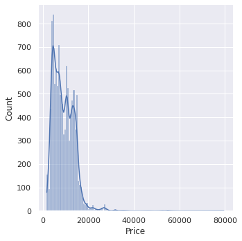

```python
sns.set_theme()
sns.set(rc = {'figure.figsize':(10,7)})
sns.displot(flights_df['Price'], kde=True)
```

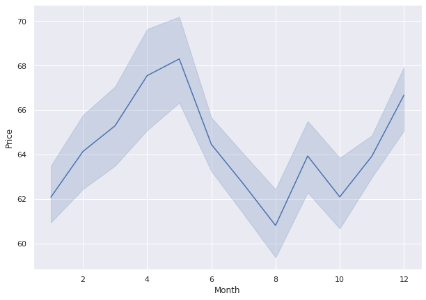

```python
oil_df['Month'] = pd.to_datetime(oil_df['Date']).dt.month
sns.lineplot(x='Month', y='Price', data = oil_df)
```

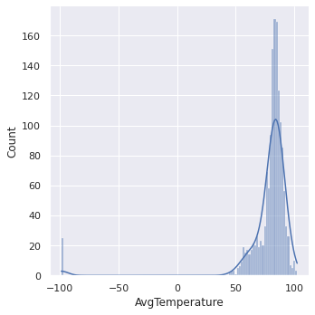

```python
sns.displot(temp_df['AvgTemperature'], kde=True)
```

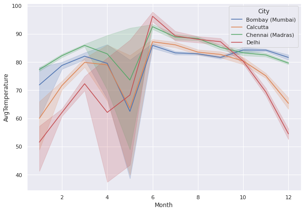

```python
temp_df['Date'] = temp_df[['Day', 'Month', 'Year']].apply(lambda row: '-'.join(row.values.astype(str)), axis=1)
sns.lineplot(data=temp_df[['Month',
                          'AvgTemperature',
                          'City']],
             x='Month',y='AvgTemperature', hue='City')
```

### Part 4 - Merge the data

Now that you have a better feel for each of your two (or three, for the 7394 students) data sets, it is time to merge them. Describe your strategy for merging the data sets and then actually perform the merge.

Develop a strategy for verifying that the data is properly merged (hoping and finger-crossing are not valid strategies).

#### Merging flights & oil prices

```python
oil_df['Date']
```

```
8024    02-01-2019
8025    03-01-2019
8026    04-01-2019
8027    07-01-2019
8028    08-01-2019
           ...
8277    25-12-2019
8278    26-12-2019
8279    27-12-2019
8280    30-12-2019
8281    31-12-2019
Name: Date, Length: 258, dtype: object
```

```python
shared_dates = list(set(oil_df['Date']) & set(flight_dates))
print("Found {} shared dates out of a total of {} unique dates".format(len(shared_dates) ,len(set(flight_dates))) )
```

```
Found 28 shared dates out of a total of 40 unique dates
```

```python
gas_price = []
for date in flight_dates:
    if date in shared_dates:
        gas_price.append(oil_df[oil_df['Date']==date]['Price'].values[0])
    else:
        gas_price.append( np.mean(oil_df['Price']) )
len(gas_price)
```

```
10682
```

```python
combined_df = flights_df.copy(deep = True)

combined_df['Gas_Price'] = gas_price
```

```python
combined_df.head()
```

|  | Airline | Date_of_Journey | Source | Destination | Route | Total_Stops | Additional Info | Price | Dep_Time_h | Dep_Time_m | Arv_Time_h | Arv_Time_m | Duration_mins | Gas_Price |
| --- | --- | --- | --- | --- | --- | --- | --- | --- | --- | --- | --- | --- | --- | --- |
| 0 | IndiGo | 2019-03-24 | Banglore | New Delhi | BLR → DEL | non-stop | No info | 3898 | 22 | 20 | 1 | 10 | 170 | 64.319845 |
| 1 | Air India | 2019-05-01 | Kolkata | Banglore | CCU → IXR → BBI → BLR | 2 stops | No info | 7663 | 5 | 50 | 13 | 15 | 445 | 72.010000 |
| 2 | Jet Airways | 2019-06-09 | Delhi | Cochin | DEL → LKO → BOM → COK | 2 stops | No info | 13883 | 9 | 25 | 4 | 25 | 1140 | 64.319845 |
| 3 | IndiGo | 2019-05-12 | Kolkata | Banglore | CCU → NAG → BLR | 1 stop | No info | 6219 | 18 | 5 | 23 | 30 | 325 | 64.319845 |
| 4 | IndiGo | 2019-03-01 | Banglore | New Delhi | BLR → NAG → DEL | 1 stop | No info | 13303 | 16 | 50 | 21 | 35 | 285 | 63.710000 |

#### Merging (flight + oil prices) & temperature data

```python
temp_df['City'].replace(list(['Bombay (Mumbai)', 'Calcutta', 'Chennai (Madras)']), ['Mumbai', 'KolKata','Chennai'], inplace=True)
print('new city names: {}'.format(temp_df['City'].unique()))

temp_cities = list(temp_df['City'].unique())
temp_df['Date'] = pd.to_datetime(temp_df['Date'], format='%d-%m-%Y').dt.strftime('%d-%m-%Y')
```

```
new city names: ['Mumbai' 'KolKata' 'Chennai' 'Delhi']
```

```python
src_temp = []
dest_temp = []

temp_shared_dates = list(set(temp_df['Date']) & set(flight_dates))

for idx, flight in flights_df.iterrows():

    if flight_dates[idx] in temp_shared_dates:

        temps_at_date = temp_df[ temp_df['Date'] == flight_dates[idx] ]
        temperature = 0

        if flight['Source'] in temp_cities:
            row = temps_at_date[ temps_at_date['City'] == flight['Source'] ]
            temperature = row['AvgTemperature'].to_numpy()[0]
        else:
            temperature = np.mean( temps_at_date['AvgTemperature'].values )

        src_temp.append(temperature)

        if flight['Destination'] in temp_cities:
            row = temps_at_date[ temps_at_date['City'] == flight['Destination'] ]
            temperature = row['AvgTemperature'].to_numpy()[0]

        else:
            temperature = np.mean( temps_at_date['AvgTemperature'].values )

        dest_temp.append(temperature)
```

```python
print('{} source temperature values\n{} destination temperature values\n'.format(len(src_temp), len(dest_temp)))

print('some source temperatures {}\n'.format(src_temp[:3]))
print('some destination temperatures {}\n'.format(dest_temp[:3]))
```

```
10682 source temperature values
10682 destination temperature values

some source temperatures [83.42500000000001, 89.775, 99.4]

some destination temperatures [83.42500000000001, 89.775, 93.275]
```

And now merging our extracted data points to the combined DataFrame.

```python
flights_df['Source'].unique()
```

```
array(['Banglore', 'Kolkata', 'Delhi', 'Chennai', 'Mumbai'], dtype=object)
```

```python
combined_df['Src_Temperature'] = src_temp
combined_df['Dest_Temperature'] = dest_temp
combined_df.head()
```

|  | Airline | Date_of_Journey | Source | Destination | Route | Total_Stops | Additional Info | Price | Dep_Time_h | Dep_Time_m | Arv_Time_h | Arv_Time_m | Duration_mins | Gas_Price | Src_Temperature | Dest_Temperature |
| --- | --- | --- | --- | --- | --- | --- | --- | --- | --- | --- | --- | --- | --- | --- | --- | --- |
| 0 | IndiGo | 2019-03-24 | Banglore | New Delhi | BLR → DEL | non-stop | No info | 3898 | 22 | 20 | 1 | 10 | 170 | 64.319845 | 83.425 | 83.425 |
| 1 | Air India | 2019-05-01 | Kolkata | Banglore | CCU → IXR → BBI → BLR | 2 stops | No info | 7663 | 5 | 50 | 13 | 15 | 445 | 72.010000 | 89.775 | 89.775 |
| 2 | Jet Airways | 2019-06-09 | Delhi | Cochin | DEL → LKO → BOM → COK | 2 stops | No info | 13883 | 9 | 25 | 4 | 25 | 1140 | 64.319845 | 99.400 | 93.275 |
| 3 | IndiGo | 2019-05-12 | Kolkata | Banglore | CCU → NAG → BLR | 1 stop | No info | 6219 | 18 | 5 | 23 | 30 | 325 | 64.319845 | 89.425 | 89.425 |
| 4 | IndiGo | 2019-03-01 | Banglore | New Delhi | BLR → NAG → DEL | 1 stop | No info | 13303 | 16 | 50 | 21 | 35 | 285 | 63.710000 | 73.375 | 73.375 |

We have the full combined dataset. Let's check if everything looks alright.

```python
combined_df.info()
```

```
<class 'pandas.core.frame.DataFrame'>
Int64Index: 10682 entries, 0 to 10682
Data columns (total 16 columns):
 #   Column            Non-Null Count  Dtype
---  ------            --------------  -----
 0   Airline           10682 non-null  object
 1   Date_of_Journey   10682 non-null  datetime64[ns]
 2   Source            10682 non-null  object
 3   Destination       10682 non-null  object
 4   Route             10682 non-null  object
 5   Total_Stops       10682 non-null  object
 6   Additional Info   10682 non-null  object
 7   Price             10682 non-null  int64
 8   Dep_Time_h        10682 non-null  int64
 9   Dep_Time_m        10682 non-null  int64
 10  Arv_Time_h        10682 non-null  int64
 11  Arv_Time_m        10682 non-null  int64
 12  Duration_mins     10682 non-null  int64
 13  Gas_Price         10682 non-null  float64
 14  Src_Temperature   10682 non-null  float64
 15  Dest_Temperature  10682 non-null  float64
dtypes: datetime64[ns](1), float64(3), int64(6), object(6)
memory usage: 1.6+ MB
```

Everything looks good. The dataset doesn't contain any null values and the variable types are set correctly.  
Let's go over the variables again before I choose a subset to move forward with to the next part.

**Catagorical Variables**

```python
combined_df.describe(include = 'object')
```

|  | Airline | Source | Destination | Route | Total_Stops | Additional Info |
| --- | --- | --- | --- | --- | --- | --- |
| count | 10682 | 10682 | 10682 | 10682 | 10682 | 10682 |
| unique | 12 | 5 | 6 | 128 | 5 | 10 |
| top | Jet Airways | Delhi | Cochin | DEL → BOM → COK | 1 stop | No info |
| freq | 3849 | 4536 | 4536 | 2376 | 5625 | 8344 |

| x | variable | dtype | description | Part5? | Why |
| --- | --- | --- | --- | --- | --- |
| 1 | Airline | object | airline name | ☑ | It is save to assume the airline name could influence the price |
| 2 | Source | object | source city | ☑ | Some cities have cheaper/more expensive tickets based on demand, resource, and other factors |
| 3 | Destination | object | destination city | ☑ | // |
| 4 | Route | object | list of stops, if any |  | There are a lot of different unique routes (128). I don't believe the specific stop codes have significance |
| 5 | Total_Stops | object | number of stops | ☑ | The number of stops could definitely influence the flight price |
| 6 | Add. Info | object | random info (mostly "No Info" |  | Mostly useless data |

**Numerical Variables**

```python
combined_df.describe(include = ['int64','float64'])
```

|  | Price | Dep_Time_h | Dep_Time_m | Arv_Time_h | Arv_Time_m | Duration_mins | Gas_Price | Src_Temperature | Dest_Temperature |
| --- | --- | --- | --- | --- | --- | --- | --- | --- | --- |
| count | 10682.000000 | 10682.000000 | 10682.000000 | 10682.000000 | 10682.000000 | 10682.000000 | 10682.000000 | 10682.000000 | 10682.000000 |
| mean | 9088.214567 | 12.491013 | 24.409287 | 13.349186 | 24.690601 | 643.020502 | 66.559474 | 76.453162 | 75.812072 |
| std | 4611.548810 | 5.748820 | 18.767801 | 6.859317 | 16.506808 | 507.830133 | 3.439053 | 44.612226 | 44.709990 |
| min | 1760.000000 | 0.000000 | 0.000000 | 0.000000 | 0.000000 | 5.000000 | 61.660000 | -99.000000 | -99.000000 |
| 25% | 5278.000000 | 8.000000 | 5.000000 | 8.000000 | 10.000000 | 170.000000 | 64.319845 | 79.700000 | 81.950000 |
| 50% | 8373.000000 | 11.000000 | 25.000000 | 14.000000 | 25.000000 | 520.000000 | 64.510000 | 88.475000 | 88.625000 |
| 75% | 12374.000000 | 18.000000 | 40.000000 | 19.000000 | 35.000000 | 930.000000 | 69.080000 | 93.275000 | 91.075000 |
| max | 79513.000000 | 23.000000 | 55.000000 | 23.000000 | 55.000000 | 2860.000000 | 73.590000 | 100.300000 | 100.300000 |

| x | variable | dtype | description | Part5? | Why |
| --- | --- | --- | --- | --- | --- |
| 7 | Price | int64 | Fligt price, target variable | ☑ | *Target* |
| 8 | Dep_Time_h | int64 | The hour of departure | ☑ | departure hour can have an effect(ex.: early flights could be cheaper) |
| 9 | Dep_Time_m | int64 | The minute of departure |  | departure minute, not important since it's periodic and Dep_Time_hr is enough |
| 10 | Arv_Time_h | int64 | The hour of arrival | ☑ | arrival hour can have an effect(ex.: arriving late could be cheaper) |
| 11 | Arv_Time_m | int64 | The minute of arrival |  | not important for the same reasons as Dep_Time_m |
| 13 | Duration_mins | int64 | flight duration in minutes | ☑ | duration |
| 14 | Gas_Price | float64 | Gas prices | ☑ | from 2nd dataset, examine how gas prices correlate to air ticket prices |
| 15 | Src_Temperature | float64 | Temperature at source city | ☑ | from 3rd dataset, testing if a relation exist with air ticket prices |
| 16 | Dest_Temperature | float64 | Temperature at destination city | ☑ | // |

### Part 5 - Explore Bivariate relationships

- Choose a reasoned set of variables to explore further. You don't have to explore all possible pairs of variables, nor do we want to grade that much. Choose 7 - 9 variables. One should be a variable that you'd like to predict (target variable) using the others (predictor variables).
- List your predictor variables
- List your target variable
- Briefly describe why you have chosen these.

Use any of the available visualizations from Seaborn to explore the relationships between the variables. Explore the relationships among the predictor variables as well as the relationship between each predictor variable and the target variable. Which of the predictor variables are most strongly related? Are there any interesting relationships between categorical predictors and numeric predictors? If there are any dichotomous variables, does that influence any of the relationships? Are the relationships positive or negative?

Below each plot, you should provide a description and interpretation of the plot. Make sure to include why the variables in that plot were chosen and what you hope the reader would gain from it as well.

```python
target = ['Price']
predictors = [
'Airline',
'Source',
'Destination',
'Total_Stops',
'Dep_Time_h',
'Arv_Time_h',
'Duration_mins',
'Gas_Price',
'Src_Temperature',
'Dest_Temperature' ]
Index = ['Date_of_Journey']
```

```python
final_dataset = combined_df[Index + predictors + target ].copy(deep=True)
final_dataset.head()
```

|  | Date_of_Journey | Airline | Source | Destination | Total_Stops | Dep_Time_h | Arv_Time_h | Duration_mins | Gas_Price | Src_Temperature | Dest_Temperature | Price |
| --- | --- | --- | --- | --- | --- | --- | --- | --- | --- | --- | --- | --- |
| 0 | 2019-03-24 | IndiGo | Banglore | New Delhi | non-stop | 22 | 1 | 170 | 64.319845 | 83.425 | 83.425 | 3898 |
| 1 | 2019-05-01 | Air India | Kolkata | Banglore | 2 stops | 5 | 13 | 445 | 72.010000 | 89.775 | 89.775 | 7663 |
| 2 | 2019-06-09 | Jet Airways | Delhi | Cochin | 2 stops | 9 | 4 | 1140 | 64.319845 | 99.400 | 93.275 | 13883 |
| 3 | 2019-05-12 | IndiGo | Kolkata | Banglore | 1 stop | 18 | 23 | 325 | 64.319845 | 89.425 | 89.425 | 6219 |
| 4 | 2019-03-01 | IndiGo | Banglore | New Delhi | 1 stop | 16 | 21 | 285 | 63.710000 | 73.375 | 73.375 | 13303 |

#### Airline & Flight Price

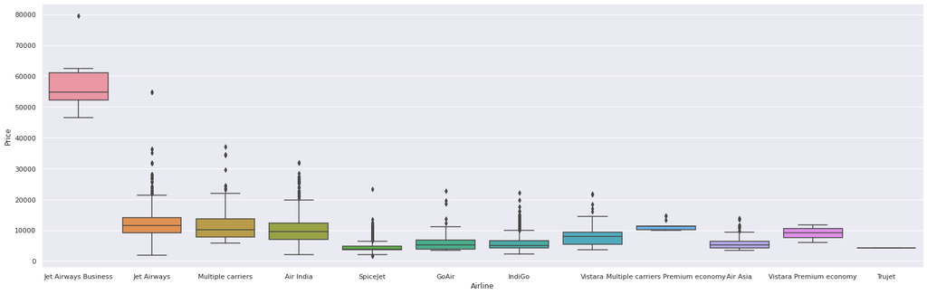

```python
sns.set(rc = {'figure.figsize':(26,8)})
sns.boxplot(x='Airline', y='Price', data = flights_df.sort_values('Price', ascending = False))
```

The plot shows that most of the airlines fall into a range of prices except for Jet Airways Business, which is significantly more expensive.

#### Source City and Price

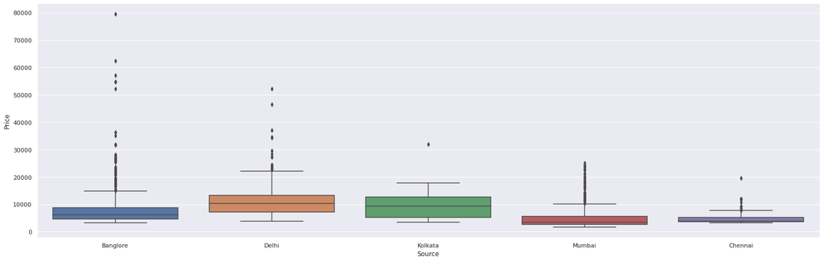

```python
sns.boxplot(x='Source', y='Price', data = final_dataset.sort_values('Price', ascending = False))
```

#### Destination City and Flight Price

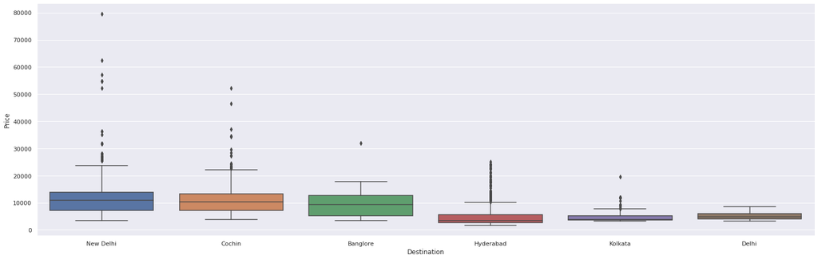

```python
sns.boxplot(x='Destination', y='Price', data = final_dataset.sort_values('Price', ascending = False))
```

#### Total Number of Stops and Flight Price

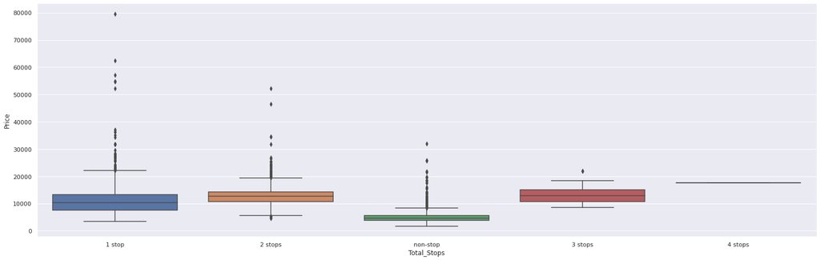

```python
sns.boxplot(x='Total_Stops', y='Price', data = final_dataset.sort_values('Price', ascending = False))
```

We can see a nice difference between the boxes in the plot. It is easy to see that the price seem to increase with the increase of stops, suggesting a direct correlation.

#### Hour of Departure and Flight Price

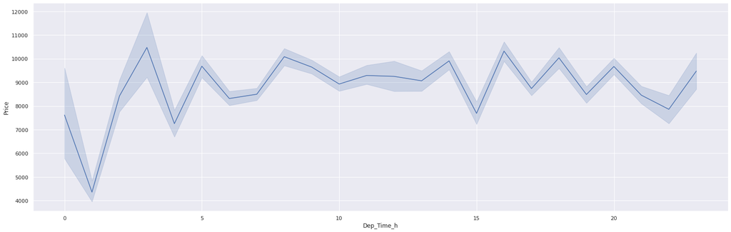

```python
sns.lineplot(x='Dep_Time_h', y='Price', data = final_dataset)
```

#### Time of Arrival and Flight Price

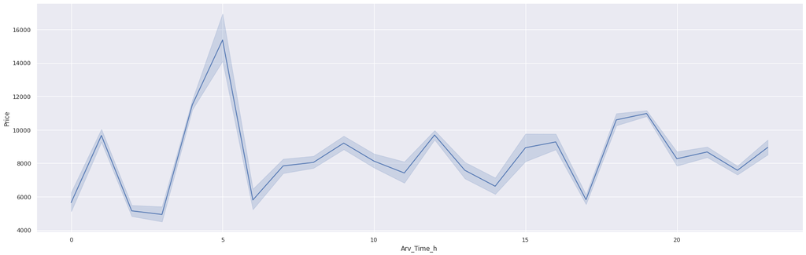

```python
sns.lineplot(x='Arv_Time_h', y='Price', data = final_dataset)
```

#### Duration and Flight Price

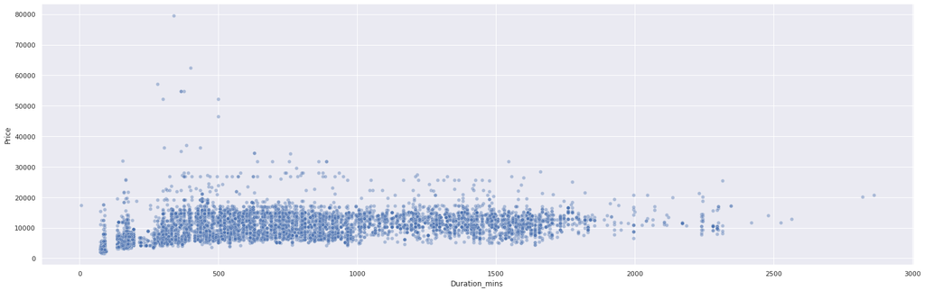

```python
sns.scatterplot(x='Duration_mins', y='Price', data = final_dataset,alpha=0.4)
```

The scatter plot above shows there isn't much variance in the price for based on duration. We can notice that the density of flights with shorter duration is higher. Flights with shorter duration also tend to have some high outliers.

Now we examine predictors from the additional datasets against the target variable from the original dataset

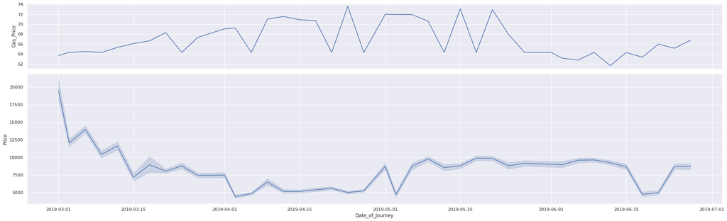

```python
f, axs = plt.subplots(2,1,
                      sharex=True,
                      gridspec_kw=dict(height_ratios=[1,2]))
sns.lineplot(data= final_dataset,
                x="Date_of_Journey", y = 'Gas_Price',
                ax=axs[0],
                legend=False)
sns.lineplot(data= final_dataset,
                x="Date_of_Journey", y="Price",
                ax=axs[1] )
f.tight_layout()
```

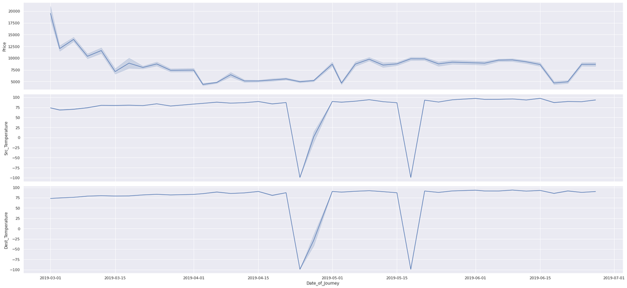

```python
f, axs = plt.subplots(3,1,
                    figsize=((26,12)),
                    sharex=True,
                    gridspec_kw=dict(height_ratios=[1,1,1]))

sns.lineplot(data= final_dataset,
                x="Date_of_Journey", y = 'Price',
                ax=axs[0],
                legend=False)

sns.lineplot(data= final_dataset,
                x="Date_of_Journey", y="Src_Temperature",
                ax=axs[1] )

sns.lineplot(data= final_dataset,
                x="Date_of_Journey", y="Dest_Temperature",
                ax=axs[2] )

f.tight_layout()
```

The plot above draws source and destination temperatues as well as prices over time on one axis. Unfortunately, there seem to be a problem with the temperature data, there are two points per each column that has an element set to -99F. The missed up data point make it harder to see patterns.

This is a speculation, but this could be 99F that was turned negative somehow. Anyway, 99F seems reasonable giving the neighboring values, also there are no negative values so I will go simple and just do abs().

```python
final_dataset['Dest_Temperature'] = np.abs(final_dataset['Dest_Temperature'])
final_dataset['Src_Temperature'] = np.abs(final_dataset['Src_Temperature'])
```

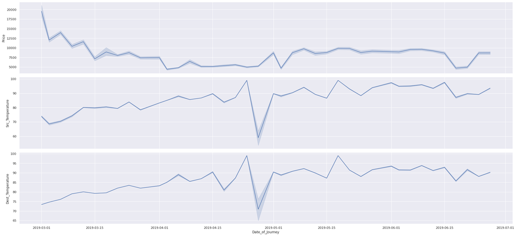

```python
f2, axs = plt.subplots(3,1,
                    figsize=((26,12)),
                    sharex=True,
                    gridspec_kw=dict(height_ratios=[1,1,1]))

sns.lineplot(data= final_dataset,
                x="Date_of_Journey", y = 'Price',
                ax=axs[0],
                legend=False)

sns.lineplot(data= final_dataset,
                x="Date_of_Journey", y="Src_Temperature",
                ax=axs[1] )

sns.lineplot(data= final_dataset,
                x="Date_of_Journey", y="Dest_Temperature",
                ax=axs[2] )

f2.tight_layout()
```

Much better! Ok, now we can see a slight negative correlation between temperature and flight prices. In other words, flights are cheaper on hot days that cooler ones. This is another interesting observation gained from the datasets merging.